# GDP Growth and Unemployment in the Netherlands and Western Europe (2015–2025)

Jakob, Ben, and David

2026-06-17

# GDP Growth and Unemployment in the Netherlands and Western Europe

**Authors:** Jakob Vahtera Persson, Ben Akyureklier, David Craveiro

**Tutorial group:** 2_5

**Tutorial lecturer:** F. Amankour (Fatima)

# Part 1 - Identify a Social Problem

## 1.1 Describe the Social Problem

Unemployment is one of the most closely watched indicators of economic well-being, because joblessness carries costs that go beyond lost income: it is associated with poorer mental and physical health, lower lifetime earnings, and weaker social cohesion (Eurofound, 2017). A central question for policymakers is how unemployment responds to the wider economy. Okun’s Law describes a stable negative relationship between output growth and unemployment (Okun, 1962): when GDP grows, unemployment tends to fall, and vice versa.

Understanding the strength of this link matters for policy. If unemployment reacts sharply to downturns, governments may need stronger automatic stabilisers; if it reacts weakly — as during the 2020 COVID-19 shock, when wage-subsidy schemes kept workers employed — the usual relationship can break down. This report quantifies the relationship between GDP growth and unemployment in the Netherlands (2015-2025), compares unemployment across Western Europe, and examines how youth workers are disproportionately exposed.

Existing work establishes Okun’s Law as a broad empirical regularity, but two gaps remain underexplored. First, the coefficient is not stable across countries: estimates for the Netherlands differ markedly from euro-area averages, yet country-specific deviations are often glossed over in cross-country studies (Ball et al., 2017). Second, the COVID-19 period may represent a structural break rather than a normal cyclical episode, since large-scale job-retention schemes severed the usual output–unemployment link in ways the pre-2020 literature could not anticipate. This report addresses both by focusing on a single country and treating 2020 as a potential break rather than a data point on a stable line.

# Part 2 - Data Sourcing

## 2.1 Load in the data

We use three datasets downloaded from Eurostat, the statistical office of the European Union. The exact tables are:

- Real GDP growth rate: Eurostat table `tec00115` (annual % change).
- Total unemployment rate: Eurostat table `tesem120`.
- Youth unemployment rate (ages 15-24): Eurostat table `tipslm80`.

## 2.2 Provide a short summary of the dataset(s)

Each dataset reports an annual percentage value per country. The unemployment series express the number of unemployed as a share of the active labour force; the GDP series expresses the annual percentage change in real GDP. All values are sourced from Eurostat and cover the period 2015-2025.

## 2.3 Describe the type of variables included

The variables are socio-economic indicators. Unemployment figures come from the EU Labour Force Survey, a large harmonised household survey, while GDP figures come from national accounts compiled by national statistical institutes. The data is therefore official administrative/survey data, comparable across countries, rather than self-reported by individuals.

# Part 3 - Quantifying

## 3.1 Data cleaning

All cleaning steps were run in the data pipeline at the top of this file to keep the workflow reproducible. For each dataset we (1) filtered for the Netherlands, (2) kept only the year and value columns, (3) recoded the placeholder -99 as NA and dropped missing values, and (4) joined the three series by year.

Two of these decisions are worth questioning. Dropping rows where the value is missing is the simplest option, but for such a short annual series it discards information; multiple imputation or carrying the series forward could preserve sample size, at the cost of inventing values we cannot verify. More importantly, recoding the placeholder −99 as NA throws away the reason a value was missing: Eurostat uses distinct flags for “not available”, “confidential”, and “low reliability”, and collapsing them into a single NA loses that signal. A refinement would be to retain the original status flags and decide case-by-case, rather than treating all missingness as equivalent.

## 3.2 Generate necessary variables

Variable 1: Youth Vulnerability Ratio

Variable 2: Annual change in unemployment (percentage points)

We construct the year-on-year change in the unemployment rate (`Ppt_Change`) to capture labour-market dynamics rather than levels. It is created in the event-analysis chunk in 3.6 using `Unemp_Rate - lag(Unemp_Rate)`, and is used to quantify how sharply unemployment moved around the 2020 shock.

## 3.3 Visualize temporal variation

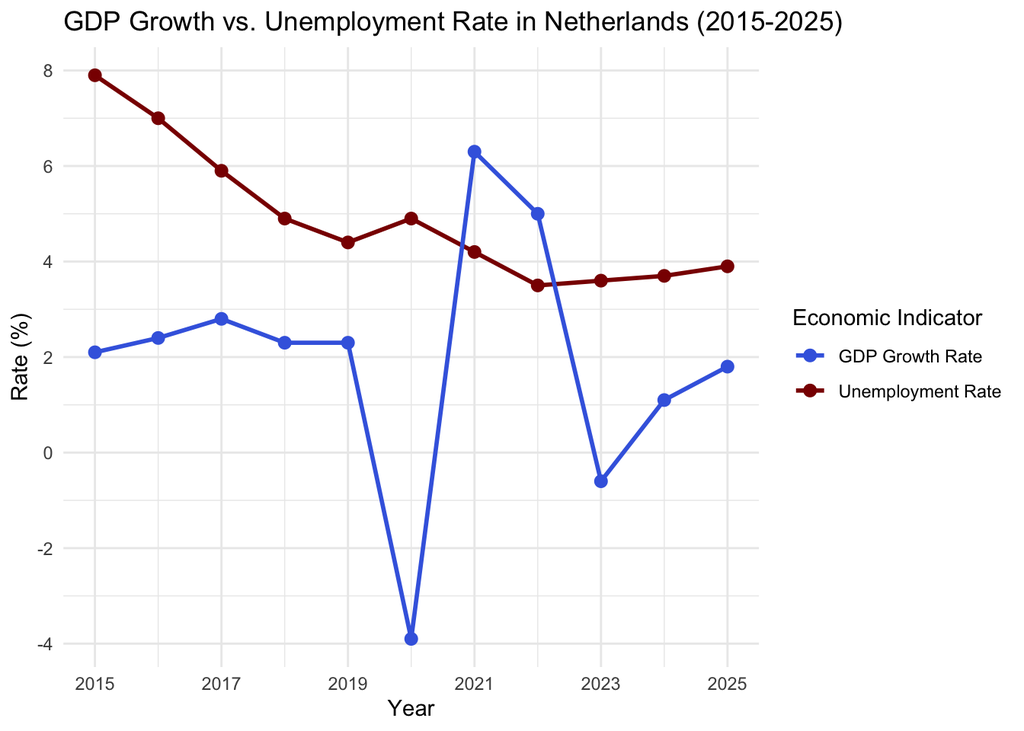